# Finding Associations Between Individual Factors, Virtual Driving Behaviors, and On-Road Outcomes

Natalie Oppenheimer

### Overview

This project explores the relative risk of a novice driver experiencing a crash based on individual factors like their age, sex, and performance on the on-road licensing exam (ORE), as well as their performance on a virtual driving test. The data set is a linked and de-identified sample of ~36,000 drivers across the state of Ohio who interacted with the state’s Bureau of Motor Vehicles (BMV) in 2017-2018. The data set contains 1) Licensing information - on-road exam scores & outcomes, number of attempts, age at attempt(s), etc. 2) Virtual Driving Test (VDT) information - performance, speed, score, etc. 3) Police-reported crash information - type, location, severity, weather, etc.

I sought input from: 1) Dr. Allison Curry, a CHOP Epidemiologist who studies motor vehicle crashes in non-typically developing populations (ex. individuals with ADD, ADHD, and Autism). 2) Dr. Kate McDonald, associate Professor at Penn’s School of Nursing who was deeply involved in the evolution of the virtual driving test from a lab-based simulator to a portable assessment tool in the field. 3) Dr. Megan Ryerson, Associate Dean for Research at PennDesign, within the Weitzman School of Design who is a city planning, urban design, and transportation expert.

Dr. Curry suggested I explore categorical groups within the data, which led to my decision to “bucket” the sample into age categories rather than exclusively treat this as a continuous variable. Dr. McDonald recommended finding explicit ties, where possible, between observed behavior/skills in the VDT and driving outcomes after licensure. For example, if someone does not maintain a safe following distance in the VDT, might they be more likely to go on to have a police-reported crash outcome involving read-end collision? Dr. Ryerson’s team brought up potential variation across the various licensing test sites, and even across individual examiners. We know from the literature that the ORE is not standardized, and certain testing sites or examiners may be - perhaps significantly - more or less stringent than average.

[final project GitHub repository](https://github.com/natalieopp/BMIN503_Final_Project)

### Introduction

Motor vehicle crashes remain the leading cause of injury and death among young adults ([WHO, 2018](https://www.who.int/publications/i/item/9789241565684)). Research estimates that motor vehicle crashes (MVCs) account for between one in three to one in five adolescent deaths; and we know that lifetime crash risk is highest in the months immediately following independent licensure ([CDC WISQARS](https://webappa.cdc.gov/sasweb/ncipc/leadcaus10_us.html), [Curry et al, 2011](https://pubmed.ncbi.nlm.nih.gov/21545856/)). We also know, however, that driving is crucial for many adolescents to achieving personal independence, and to accessing educational and occupational opportunities and other resources. Therefore, a crucial public health question emerges: how can we increase young driver safety without compromising mobility? One intervention, Graduated Driver Licensing (GDL), has been implemented across the United States. GDL aims to “allow young drivers to safely gain driving experience before obtaining full driving privileges” through a staged approach to driving beginning with learner or permit-ed, supervised driving, followed by intermediate limited license, and finally full privilege license (Governors Highway Safety Association). GDL has successfully reduced the number of MVCs among 16- and 17-year old drivers, but this policy does not necessarily ensure that new drivers acquire the skills needed to drive safely, as evidenced by the fact that the vast majority of crashes in the months immediately after licensure are due to driver error (as opposed to driver risk-taking)([Gershon et al, 2018](https://www.sciencedirect.com/science/article/abs/pii/S1054139X18301897)). This suggests that the point of licensure is a critical moment for assessing new driver skills to ensure they are ready to safely begin independent driving. Unfortunately, the ORE is extremely limited in its ability to test for these key skills due to variability in examiner assessment of applicant readiness to drive, time constraints, the inability to safely expose applicants to common crash risk scenarios, and a host of other factors. To combat some of these limitations, simulated driving assessment can be used to complement the ORE by consistently and safely exposing applicants to common crash risk scenarios, and thoroughly evaluating their driving skills ([McDonald et al, 2012](https://journals.sagepub.com/doi/10.3141/2321-10)).

Through a partnership between Diagnostic Driving, Inc., a CHOP spin-out company, the Ohio Bureau of Motor Vehicles (OBMV), and the CHOP Neuroscience of Driving (NoD) team, such a simulated driving assessment was implemented in driving test sites across the state of Ohio ([Walshe et al, 2020](https://www.healthaffairs.org/doi/abs/10.1377/hlthaff.2020.00802)). This interdisciplinary team combined a variety of experiences and perspectives including public health, traffic safety & public policy, health technology research, cognitive & neuroscience, and developmental medicine. Our shared goal: scale and sustain the virtual driving test (VDT) as a screener and skills assessment at the time of licensure to identify applicants with critical skill deficits who are at risk of failing the ORE, and/or may be at a higher risk of crashing post-licensure. In order to do this, CHOP has received, linked, and de-identified a) data from Ohio’s state-wide licensing database, b) Ohio’s police-reported crash outcomes, c) Diagnostic Driving’s VDT process and outcome data. Utilizing this rich and unique data source, we aim to address a number of crucial research questions with potential major policy implications: How do crash rates vary by personal factors such as sex, age at licensure, time since licensure, and VDT performance? Are these factors (sex, age, time since licensure, VDT performance) related, and if so, what does this tell us about young driver skill development and experience?

### Methods

The data set used for this project is a consists of linked, de-identified data from three sources: 1. VDT data from Diagnostic Driving, Inc. 2. Licensing data from OBMV 3. Police-reported crash outcome data from ODPS See the README for additional details about these data sources and the linking & honest brokering process.

Analyses are conducted on two sample groups within the data set:

1. All applicants who took the VDT
- Age breakdown
- Sex breakdown
- Crashes in the VDT by age & sex
2. Applicants who went on to have a MVC
- Age breakdown
- Sex breakdown
- Crashes on-road by age & sex
- VDT variables related to skill deficits associated with corresponding on-road outcomes

Note: In order to simplify this analysis and maintain the focus on young novice drivers, an upper bound of 25 years old at the time of the VDT/ORE was implemented.

```r
# set-up and basic cleaning/formatting

# loading in libraries used
library(dplyr)
library(ggplot2)

# reading in combined VDT, licensing, crash outcomes data set
d <- read.csv(file = 'Research_dataset_HSG.csv')

# checking variable class for cleaning (printing head to save space)
head(lapply(d, class))
```

```
## $customer_deidentified
## [1] "character"
##
## $TestDateAge
## [1] "integer"
##
## $vdt_test_year
## [1] "integer"
##
## $DxD_cohort
## [1] "integer"
##
## $BMVLocation
## [1] "character"
##
## $completed_intro_drive
## [1] "character"
```

```r
# cleaning & re-coding variables
dc <- d %>%
  mutate(TestDateAge = (TestDateAge/365.25),
         BMVLocation = as.factor(BMVLocation),
         completed_intro_drive = as.factor(completed_intro_drive),
         started_comprehension = as.factor(started_comprehension),
         completed_comprehension = as.factor(completed_comprehension),
         started_assessment_drive = as.factor(started_assessment_drive),
         completed_assessment_drive = as.factor(completed_assessment_drive),
         passed_comprehension = as.factor(passed_comprehension),
         Map = as.factor(Map),
         Variant = as.factor(Variant)) %>%
  rename(Total_VDT_Duration = Total_Duration,
         U_ttc_3_10 = U_CE_3_10,
         U_120_over_limit = U_spd_limit_120,
         U_no_scan = U_f2scan_X,
         VDT_score_timeseries = VDT_score_tsc) %>%
  mutate(Sex = as.factor(Sex),
         IsManeuverPassing = factor(IsManeuverPassing, levels = c(0, 1),
                                    labels = c("Fail", "Pass"))) %>%
  rename(Maneuvertest_attempt = Maneuvertest_seq) %>%
  mutate(IsDrivingPassing = factor(IsDrivingPassing, levels = c(0, 1),
                                   labels = c("Fail", "Pass"))) %>%
  rename(Drivingtest_attempt = Drivingtest_seq,
         VDTtest_attempt = VDTtest_seq) %>%
  mutate(LicenseType = factor(LicenseType, levels = c("O", "G", "F", "R"),
                              labels = c("Full License", "Temporary Permit", "License Duplicate", "License Renewal"))) %>%
  rename(LicenseClass = ClassNew) %>%
  mutate(DLIssueDateAge = (DLIssueDateAge/365.25),
         FirstPermitStartAge = (FirstPermitStartAge/365.25),
         CurrentPermitStartAge = (CurrentPermitStartAge/365.25),
         AgeAtFirstORE_currentPermit = (AgeAtFirstORE_currentPermit/365.25),
         AgeAtLastORE_currentPermit = (AgeAtLastORE_currentPermit/365.25),
         AgeAtFirstORE_allPermits = (AgeAtFirstORE_allPermits/365.25),
         AgeAtLastORE_allPermits = (AgeAtLastORE_allPermits/365.25),
         DrivingSchoolFlag = factor(DrivingSchoolFlag, levels = c(0, 1),
                                    labels = c("Complete", "Not Complete")),
         PreExistingDLFlag = factor(PreExistingDLFlag, levels = c(0, 1),
                                    labels = c("PreExisting DL", "No PreExisting DL")),
         CrashDateAge = (CrashDateAge/365.25),
         Crash_Severity = as.factor(Crash_Severity),
         Crash_LightCondition = as.factor(Crash_LightCondition),
         Crash_RoadCondition = as.factor(Crash_RoadCondition),
         Crash_Weather = as.factor(Crash_Weather),
         Crash_Location = as.factor(Crash_Location),
         Crash_MannerOfCollision = as.factor(Crash_MannerOfCollision),
         Vehicle_type = as.factor(Vehicle_type),
         Vehicle_DamageScale = as.factor(Vehicle_DamageScale),
         Vehicle_Make = as.factor(Vehicle_Make),
         Vehicle_Model = as.factor(Vehicle_Model),
         Vehicle_Pre_Crash_Action = as.factor(Vehicle_Pre_Crash_Action),
         Vehicle_SequenceOfEvent_1 = as.factor(Vehicle_SequenceOfEvent_1),
         Vehicle_SequenceOfEvent_2 = as.factor(Vehicle_SequenceOfEvent_2),
         Vehicle_Circumstances = as.factor(Vehicle_Circumstances),
         Driver_InjuryType = as.factor(Driver_InjuryType),
         Driver_condition = as.factor(Driver_condition),
         Driver_Distraction = as.factor(Driver_Distraction),
         Driver_InjuryTransportation = as.factor(Driver_InjuryTransportation),
         Driver_AirbagDeploy = as.factor(Driver_AirbagDeploy),
         Driver_Ejection = as.factor(Driver_Ejection))
```

Now that the variables are reformatted for analysis, the data needs to be cleaned.

```r
# cleaning data based on missingness in key variables to create cohorts

# cohort 1 - all VDT-takers
# cleaning for Age and Sex:
  # has a value for Sex
  # was between 16-25 at time of VDT/ORE
dcl <- dc %>%
  filter(between(TestDateAge,16,25)) %>%
  filter(Sex != "")
# cleaning for VDT: completed the entire test/course
dcl <- dcl %>%
  filter(completed_assessment_drive == "y")
# new variable: creating age "buckets"
dcl$TestDateAgeBucket <- cut(dcl$TestDateAge,
                             breaks = c(15.9, 16.49, 16.99, 17.49, 17.99, 19, 21, 25),
                             labels = c("16.0-16.5", "16.5-17", "17-17.5", "17.5-18", "18-19", "19-21", "21-25"))

# cohort 2 - experienced a police-reported crash (within available data)
crashers <- dcl %>%
  filter(!is.na(CrashDateAge))
```

Building plots for cohort 1:

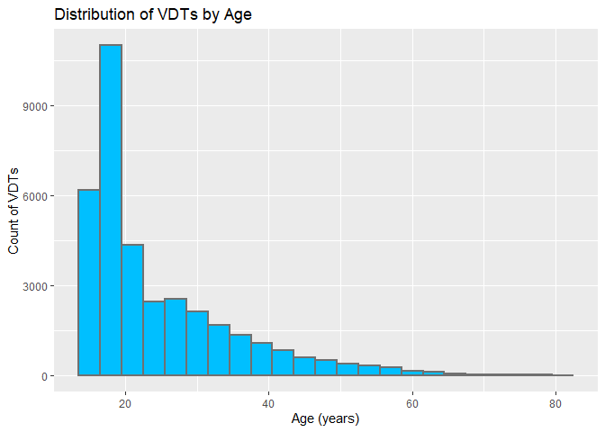

```r
# VDT by age breakdown across the entire data set
age_overall <- ggplot(data = dc, aes(x = TestDateAge)) +
  geom_histogram(binwidth = 3, col = "gray44", fill = "deepskyblue", size = 1)
print(age_overall + labs(title = "Distribution of VDTs by Age",
                         y = "Count of VDTs",
                         x = "Age (years)"))
```

This confirms that the majority of VDTs were taken by applicants aged 25 and younger. Next, we’ll look at the distribution within just that younger sample considering age as both a continuous and categorical variable.

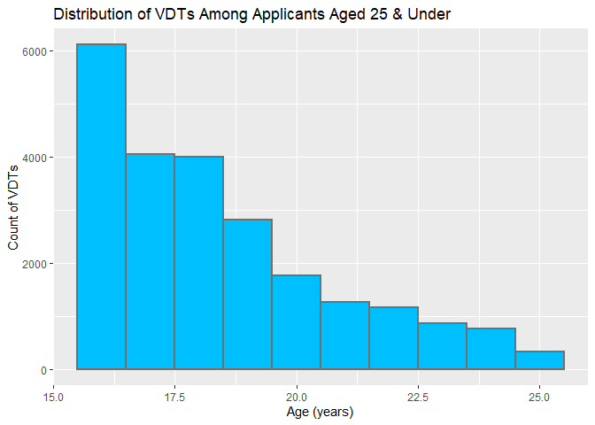

```r
# VDT by age across sub-sample of interest (25 and under)
age_under25 <- ggplot(data = dcl, aes(x = TestDateAge)) +
  geom_histogram(binwidth = 1, col = "gray44", fill = "deepskyblue", size = 1)
print(age_under25 + labs(title = "Distribution of VDTs Among Applicants Aged 25 & Under",
                         y = "Count of VDTs",
                         x = "Age (years)"))
```

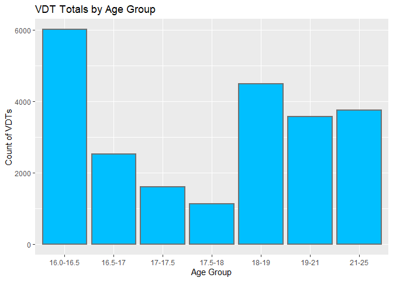

```r
# VDT by age "buckets"
age_buckets <- ggplot(data = dcl, aes(x = TestDateAgeBucket)) +
  geom_bar(col = "gray44", fill = "deepskyblue", size = 1)
print(age_buckets + labs(title = "VDT Totals by Age Group",
                         y = "Count of VDTs",
                         x = "Age Group"))
```

This distribution fits with our expectations based on knowledge of Ohio’s GDL and driver training laws. We see the biggest spike at 16, the age when individuals become eligible to take the ORE and earn an driver’s license after completing driver training and their learners permit phase. We also see a second spike at 18, the age at which applicants can take the ORE without completing mandatory behind-the-wheel driver training or holding a learner’s permit.

Next, let’s look at how this group breaks down by sex:

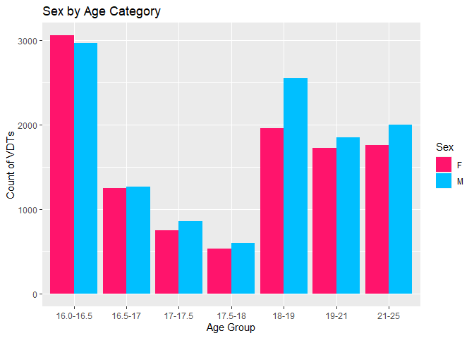

```r
cols <- c("#ff146c", "deepskyblue")
sex_age <- ggplot(data = dcl, aes(x = TestDateAgeBucket, fill = Sex)) +
  geom_bar(position = "dodge") +
  scale_fill_manual(values = cols) +
  ggtitle("Sex by Age Category") +
  xlab("Age Group") +
  ylab("Count of VDTs")
sex_age
```

```r
# taking a closer look at sex in the 18-19 year old category
length(dcl$customer_deidentified[dcl$Sex == "M" & dcl$TestDateAgeBucket == "18-19"])
```

```
## [1] 2544
```

```r
length(dcl$customer_deidentified[dcl$Sex == "F" & dcl$TestDateAgeBucket == "18-19"])
```

```
## [1] 1959
```

With the exception of 18-19 year olds, sex is about evenly distributed across the age groups.

Next we’ll look at performance across these groups on both the VDT and ORE.

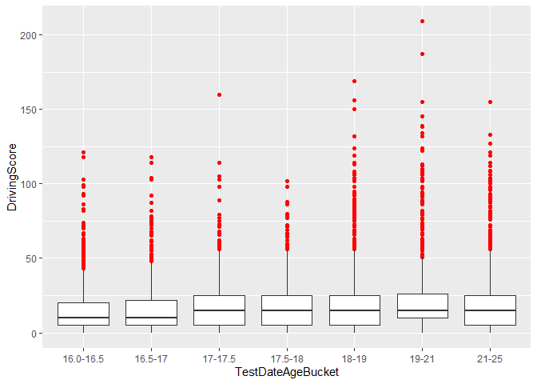

```r
# ORE scores across age categories
age_scores <- ggplot(data = dcl, aes(x = TestDateAgeBucket, y = DrivingScore)) +
  geom_boxplot(outlier.colour = "red")
age_scores
```

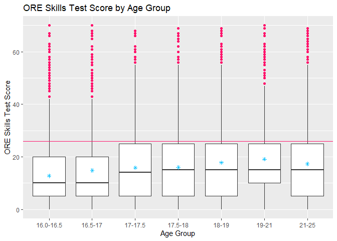

```r
# lots of outliers in every group!
# taking a cleaner & closer look at the distributions
age_scores_clean <- ggplot(data = dcl, aes(x = TestDateAgeBucket, y = DrivingScore)) +
  geom_boxplot(outlier.colour = "#ff146c") +
  scale_y_continuous(limits = c(0,70)) +
  ggtitle("ORE Skills Test Score by Age Group") +
  xlab("Age Group") +
  ylab("ORE Skills Test Score") +
  stat_summary(fun = mean, geom = "point", shape = 8, color = "deepskyblue") +
  geom_hline(yintercept = 26, color = "#ff146c")
age_scores_clean
```

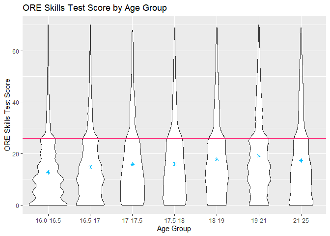

```r
# looking at a violin plot to compare group densities
age_scores_v <- ggplot(data = dcl, aes(x = TestDateAgeBucket, y = DrivingScore)) +
  geom_violin() +
  scale_y_continuous(limits = c(0,70)) +
  ggtitle("ORE Skills Test Score by Age Group") +
  xlab("Age Group") +
  ylab("ORE Skills Test Score") +
  stat_summary(fun = mean, geom = "point", shape = 8, color = "deepskyblue") +
  geom_hline(yintercept = 26, color = "#ff146c")
age_scores_v
```

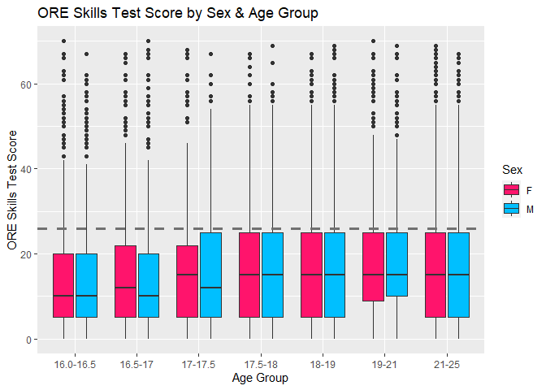

```r
# adding in age
sex_age_score <- ggplot(data = dcl, aes(x = TestDateAgeBucket, y = DrivingScore)) +
  geom_boxplot(aes(fill = Sex)) +
  scale_fill_manual(values = cols) +
  scale_y_continuous(limits = c(0,70)) +
  ggtitle("ORE Skills Test Score by Sex & Age Group") +
  xlab("Age Group") +
  ylab("ORE Skills Test Score") +
  geom_hline(yintercept = 26, color = "gray44", size = 1.2, linetype = "dashed")
sex_age_score
```

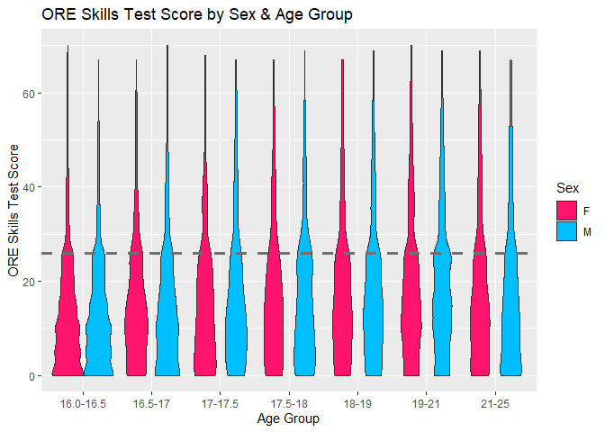

```r
# plotting corresponding violin
sex_age_score_v <- ggplot(data = dcl, aes(x = TestDateAgeBucket, y = DrivingScore)) +
  geom_violin(aes(fill = Sex)) +
  scale_fill_manual(values = cols) +
  scale_y_continuous(limits = c(0,70)) +
  ggtitle("ORE Skills Test Score by Sex & Age Group") +
  xlab("Age Group") +
  ylab("ORE Skills Test Score") +
  geom_hline(yintercept = 26, color = "gray44", size = 1.2, linetype = "dashed")
sex_age_score_v
```

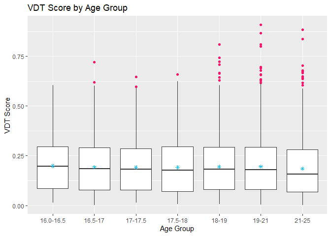

```r
# now for VDT scores - first by age
age_vdt_scores <- ggplot(data = dcl, aes(x = TestDateAgeBucket, y = VDT_score_var)) +
  geom_boxplot(outlier.colour = "#ff146c") +
  ggtitle("VDT Score by Age Group") +
  xlab("Age Group") +
  ylab("VDT Score") +
  stat_summary(fun = mean, geom = "point", shape = 8, color = "deepskyblue")
age_vdt_scores
```

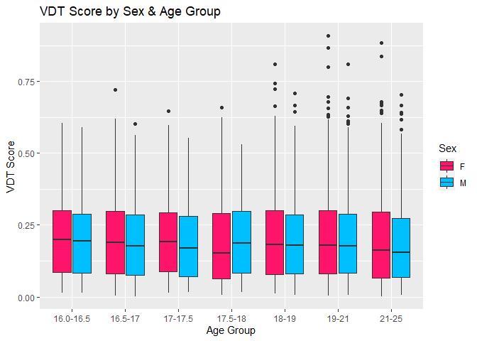

```r
#VDT scores by age & sex
age_sex_vdt_scores <- ggplot(data = dcl, aes(x = TestDateAgeBucket, y = VDT_score_var)) +
  geom_boxplot(aes(fill = Sex)) +
  scale_fill_manual(values = cols) +
  ggtitle("VDT Score by Sex & Age Group") +
  xlab("Age Group") +
  ylab("VDT Score")
age_sex_vdt_scores
```

From these plots, we can see the VDT “absorbs” much of the variability by age and sex on the ORE skills test. In other words, VDT score varies much less across sex and age category than does the ORE.

Next, we’ll look at distributions of these factors among those who passed the ORE and earned their license, but went on to have a police-reported MVC.

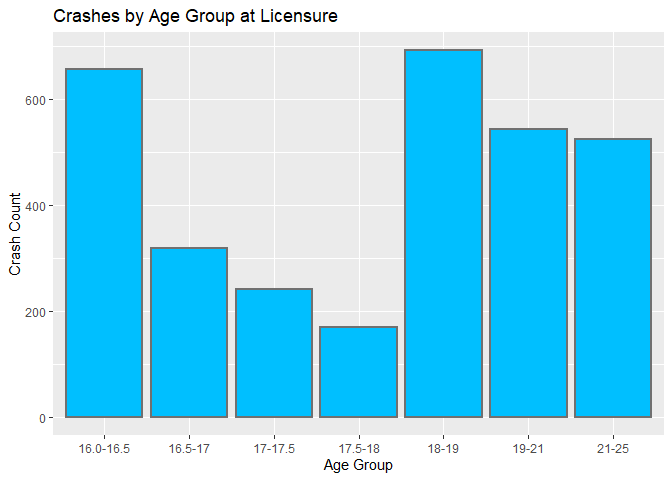

```r
# age distribution
age_crash_dist<- ggplot(data = crashers, aes(x = TestDateAgeBucket)) +
  geom_bar(col = "gray44", fill = "deepskyblue", size = 1) +
  ggtitle("Crashes by Age Group at Licensure") +
  xlab("Age Group") +
  ylab("Crash Count")
age_crash_dist
```

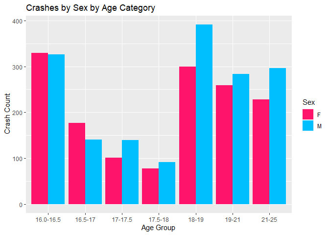

```r
#age and sex distribution
age_sex_crash_dist <- ggplot(data = crashers, aes(x = TestDateAgeBucket, fill = Sex)) +
  geom_bar(position = "dodge") +
  scale_fill_manual(values = cols) +
  ggtitle("Crashes by Sex by Age Category") +
  xlab("Age Group") +
  ylab(" Crash Count")
age_sex_crash_dist
```

One intervention that may help to mitigate these negative outcomes is providing feedback to license applicants based on their VDT performance. This feedback could prove particularly valuable if

1. It could be targeted at performance variables in the VDT, and this skills/skill deficits underlying them, that are associated with negative on-road outcomes.
2. It addresses the most common & serious crash scenarios. Therefore, we’ll seek to identify what some of these key indicators and outcomes might be.

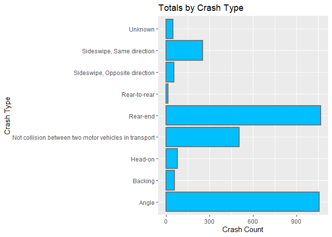

```r
# plotting counts of different types of crashes
crash_types<- ggplot(data = crashers, aes(x = Crash_MannerOfCollision)) +
  geom_bar(col = "gray44", fill = "deepskyblue", size = 1) +
  coord_flip() +
  ggtitle("Totals by Crash Type") +
  xlab("Crash Type") +
  ylab("Crash Count")
crash_types
```

The most common MVCs are: + Rear end + Angle (AKA side impacts or T-bone collisions) + Sideswipe between vehicles traveling in the same direction Note: Collisions are also common between two objects that are not both traveling vehicles (ex. one car hitting a pole, curb, parked car, hydrant, etc.). These types of collisions are also captured in the VDT, where they are referred to as “environmental objects” and collisions with these objects are calculated separately.